# Machine Learning Essentials - Exercise 3

## Part 1: Introduction

```python
import numpy as np
import pandas as pd
import matplotlib.pyplot as plt

import torch
import torch.optim as optim
from torch.utils.data import DataLoader

import torchvision.datasets as datasets
import torchvision.transforms as transforms

from torch.nn.functional import conv2d, max_pool2d, cross_entropy
```

### Load MNIST

```python
plt.rc("figure", dpi=100)

batch_size = 100

# transform images into normalized tensors
transform = transforms.Compose([
    transforms.ToTensor(),
    transforms.Normalize(mean=(0.5,), std=(0.5,))
])

train_dataset = datasets.MNIST(
    "./",
    download=True,
    train=True,
    transform=transform,
)

test_dataset = datasets.MNIST(
    "./",
    download=True,
    train=False,
    transform=transform,
)

train_dataloader = DataLoader(
    dataset=train_dataset,
    batch_size=batch_size,
    shuffle=True,
    num_workers=1,
    pin_memory=True,
)

test_dataloader = DataLoader(
    dataset=test_dataset,
    batch_size=batch_size,
    shuffle=False,
    num_workers=1,
    pin_memory=True,
)
```

### Helper functions

```python
def init_weights(shape):
    # Kaiming He initialization (a good initialization is important)
    # https://arxiv.org/abs/1502.01852
    std = np.sqrt(2. / shape[0])
    w = torch.randn(size=shape) * std
    w.requires_grad = True
    return w


def rectify(x):
    # Rectified Linear Unit (ReLU)
    return torch.max(torch.zeros_like(x), x)

class RMSprop(optim.Optimizer):
    """
        This is a reduced version of the PyTorch internal RMSprop optimizer
        It serves here as an example
    """
    def __init__(self, params, lr=1e-3, alpha=0.5, eps=1e-8):
        defaults = dict(lr=lr, alpha=alpha, eps=eps)
        super(RMSprop, self).__init__(params, defaults)

    def step(self):
        for group in self.param_groups:
            for p in group['params']:
                grad = p.grad.data
                state = self.state[p]

                # state initialization
                if len(state) == 0:
                    state['square_avg'] = torch.zeros_like(p.data)

                square_avg = state['square_avg']
                alpha = group['alpha']

                # update running averages
                square_avg.mul_(alpha).addcmul_(grad, grad, value=1 - alpha)
                avg = square_avg.sqrt().add_(group['eps'])

                # gradient update
                p.data.addcdiv_(grad, avg, value=-group['lr'])
```

### Model

```python
# define the neural network
def model(x, w_h, w_h2, w_o):
    h = rectify(x @ w_h)
    h2 = rectify(h @ w_h2)
    pre_softmax = h2 @ w_o
    return pre_softmax
```

### Initialize weights

```python
# input shape is (B, 784)
w_h = init_weights((784, 625))
# hidden layer with 625 neurons
w_h2 = init_weights((625, 625))
# hidden layer with 625 neurons
w_o = init_weights((625, 10))
# output shape is (B, 10)
```

### Training Loop

```python
optimizer = RMSprop(params=[w_h, w_h2, w_o])

n_epochs = 100

train_loss = []
test_loss = []

# put this into a training loop over 100 epochs
for epoch in range(n_epochs + 1):
    train_loss_this_epoch = []
    for idx, batch in enumerate(train_dataloader):
        x, y = batch

        # our model requires flattened input
        x = x.reshape(batch_size, 784)
        # feed input through model
        noise_py_x = model(x, w_h, w_h2, w_o)

        # reset the gradient
        optimizer.zero_grad()

        # the cross-entropy loss function already contains the softmax
        loss = cross_entropy(noise_py_x, y, reduction="mean")

        train_loss_this_epoch.append(float(loss))

        # compute the gradient
        loss.backward()
        # update weights
        optimizer.step()

    train_loss.append(np.mean(train_loss_this_epoch))

    # test periodically
    if epoch % 10 == 0:
        print(f"Epoch: {epoch}")
        print(f"Mean Train Loss: {train_loss[-1]:.2e}")
        test_loss_this_epoch = []

        # no need to compute gradients for validation
        with torch.no_grad():
            for idx, batch in enumerate(test_dataloader):
                x, y = batch
                x = x.reshape(batch_size, 784)
                noise_py_x = model(x, w_h, w_h2, w_o)

                loss = cross_entropy(noise_py_x, y, reduction="mean")
                test_loss_this_epoch.append(float(loss))

        test_loss.append(np.mean(test_loss_this_epoch))

        print(f"Mean Test Loss:  {test_loss[-1]:.2e}")
```

```
Epoch: 0
Mean Train Loss: 3.95e-01
Mean Test Loss:  2.85e-01
Epoch: 10
Mean Train Loss: 1.53e-01
Mean Test Loss:  3.97e-01
Epoch: 20
Mean Train Loss: 1.05e-01
Mean Test Loss:  4.97e-01
Epoch: 30
Mean Train Loss: 6.67e-02
Mean Test Loss:  5.47e-01
Epoch: 40
Mean Train Loss: 5.24e-02
Mean Test Loss:  7.29e-01
Epoch: 50
Mean Train Loss: 3.89e-02
Mean Test Loss:  8.40e-01
Epoch: 60
Mean Train Loss: 2.62e-02
Mean Test Loss:  7.34e-01
Epoch: 70
Mean Train Loss: 2.38e-02
Mean Test Loss:  8.19e-01
Epoch: 80
Mean Train Loss: 1.38e-02
Mean Test Loss:  7.55e-01
Epoch: 90
Mean Train Loss: 1.52e-02
Mean Test Loss:  8.42e-01
Epoch: 100
Mean Train Loss: 6.74e-03
Mean Test Loss:  8.78e-01
```

### Plot Losses

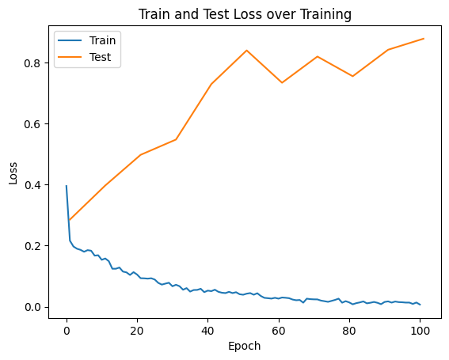

```python
plt.plot(np.arange(n_epochs + 1), train_loss, label="Train")
plt.plot(np.arange(1, n_epochs + 2, 10), test_loss, label="Test")
plt.title("Train and Test Loss over Training")
plt.xlabel("Epoch")
plt.ylabel("Loss")
plt.legend()
```

## Part 2: Dropout

```python
def dropout(X, p_drop=0.5):
    """
        Manual dropout implementation.
        Random elements are set to zero during training.
        The remaining elements are scaled by 1 / (1 - p_drop).
    """
    if 0 < p_drop < 1:
        # one random drop decision per element
        drop_mask = torch.bernoulli(torch.ones_like(X) * p_drop)
        keep_mask = 1.0 - drop_mask
        kept_X = X * keep_mask
        return kept_X / (1.0 - p_drop)
    else:
        return X
```

### Build new model with dropout functionality

```python
def dropout_model(X, w_h, w_h2, w_o, p_drop_input, p_drop_hidden):
    X = dropout(X, p_drop_input)

    h = rectify(X @ w_h)

    h = dropout(h, p_drop_hidden)

    h2 = rectify(h @ w_h2)

    h2 = dropout(h2, p_drop_hidden)

    return h2 @ w_o
```

Dropout method randomly sets some neuron outputs to `0` (deactivate) during training. The remaining active neurons are scaled up so that the total expected output stays the same.

This helps to reduce overfitting because the network cannot rely on the same neurons every time. Instead, it must learn more robust features that work well even when some connections are missing. In other words, dropout behaves like training many slightly different networks and averaging their behavior.

### Train the model using dropout and report train and test errors

```python
# reinitializing weights
w_h = init_weights((784, 625))
w_h2 = init_weights((625, 625))
w_o = init_weights((625, 10))

p_drop_input = 0.2
p_drop_hidden = 0.5

optimizer = RMSprop(params=[w_h, w_h2, w_o])

n_epochs = 100

train_loss = []
test_loss = []

# put this into a training loop over 100 epochs
for epoch in range(n_epochs + 1):
    train_loss_this_epoch = []
    for idx, batch in enumerate(train_dataloader):
        x, y = batch

        # our model requires flattened input
        x = x.reshape(batch_size, 784)
        # feed input through model
        noise_py_x = dropout_model(x, w_h, w_h2, w_o, p_drop_input, p_drop_hidden)

        # reset the gradient
        optimizer.zero_grad()

        # the cross-entropy loss function already contains the softmax
        loss = cross_entropy(noise_py_x, y, reduction="mean")

        train_loss_this_epoch.append(float(loss))

        # compute the gradient
        loss.backward()
        # update weights
        optimizer.step()

    train_loss.append(np.mean(train_loss_this_epoch))

    # test periodically
    if epoch % 10 == 0:
        print(f"Epoch: {epoch}")
        print(f"Mean Train Loss for the Dropout Model: {train_loss[-1]:.2e}")
        test_loss_this_epoch = []

        # no need to compute gradients for validation
        with torch.no_grad():
            for idx, batch in enumerate(test_dataloader):
                x, y = batch
                x = x.reshape(batch_size, 784)
                noise_py_x = model(x, w_h, w_h2, w_o)

                loss = cross_entropy(noise_py_x, y, reduction="mean")
                test_loss_this_epoch.append(float(loss))

        test_loss.append(np.mean(test_loss_this_epoch))

        print(f"Mean Test Loss for the Dropout Model:  {test_loss[-1]:.2e}")
```

```
Epoch: 0
Mean Train Loss for the Dropout Model: 7.45e-01
Mean Test Loss for the Dropout Model:  2.39e-01
Epoch: 10
Mean Train Loss for the Dropout Model: 6.90e-01
Mean Test Loss for the Dropout Model:  2.18e-01
Epoch: 20
Mean Train Loss for the Dropout Model: 8.02e-01
Mean Test Loss for the Dropout Model:  2.77e-01
Epoch: 30
Mean Train Loss for the Dropout Model: 8.97e-01
Mean Test Loss for the Dropout Model:  2.99e-01
Epoch: 40
Mean Train Loss for the Dropout Model: 1.10e+00
Mean Test Loss for the Dropout Model:  3.75e-01
Epoch: 50
Mean Train Loss for the Dropout Model: 1.15e+00
Mean Test Loss for the Dropout Model:  3.84e-01
Epoch: 60
Mean Train Loss for the Dropout Model: 1.20e+00
Mean Test Loss for the Dropout Model:  4.18e-01
Epoch: 70
Mean Train Loss for the Dropout Model: 1.25e+00
Mean Test Loss for the Dropout Model:  3.95e-01
Epoch: 80
Mean Train Loss for the Dropout Model: 1.30e+00
Mean Test Loss for the Dropout Model:  5.54e-01
Epoch: 90
Mean Train Loss for the Dropout Model: 1.33e+00
Mean Test Loss for the Dropout Model:  5.12e-01
Epoch: 100
Mean Train Loss for the Dropout Model: 1.42e+00
Mean Test Loss for the Dropout Model:  5.31e-01
```

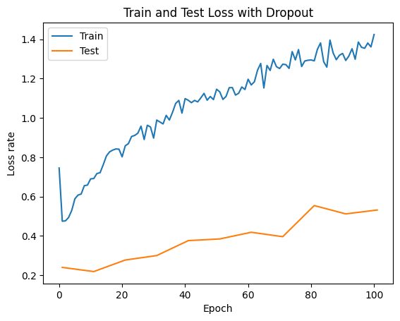

```python
plt.plot(np.arange(n_epochs + 1), train_loss, label="Train")
plt.plot(np.arange(1, n_epochs + 2, 10), test_loss, label="Test")
plt.title("Train and Test Loss with Dropout")
plt.xlabel("Epoch")
plt.ylabel("Loss rate")
plt.legend()
```

The test loss is evaluated with a different configuration because dropout is only a training-time regularizer. This approach removes the random masking so that the test score reflects the deterministic network we actually use for predicting.

Compared with part 1, the dropout model does better on the test set: part 1 finishes at about 8.78e-01test loss, while the dropout finishes at about 5.31e-01. So dropout improves the test error.

## Part 3: Parametric ReLU

```python
# define PReLU
def PRelu(X, a):
    return torch.where(X > 0, X, a * X)

# initialize learnable parameters
a1 = torch.ones(625) * 0.25
a1.requires_grad = True

a2 = torch.ones(625) * 0.25
a2.requires_grad = True

# create PReLU model
def prelu_model(X, w_h, w_h2, w_o, a1, a2):
    h = PRelu(X @ w_h, a1)

    h2 = PRelu(h @ w_h2, a2)

    return h2 @ w_o
```

```python
# reinitializing weights
w_h = init_weights((784, 625))
w_h2 = init_weights((625, 625))
w_o = init_weights((625, 10))

# add parameters to optimizer
optimizer = RMSprop(params=[w_h, w_h2, w_o, a1, a2])

n_epochs = 100

train_loss = []
test_loss = []

# put this into a training loop over 100 epochs
for epoch in range(n_epochs + 1):
    train_loss_this_epoch = []
    for idx, batch in enumerate(train_dataloader):
        x, y = batch

        # our model requires flattened input
        x = x.reshape(batch_size, 784)
        # feed input through model
        noise_py_x = prelu_model(x, w_h, w_h2, w_o, a1, a2)

        # reset the gradient
        optimizer.zero_grad()

        # the cross-entropy loss function already contains the softmax
        loss = cross_entropy(noise_py_x, y, reduction="mean")

        train_loss_this_epoch.append(float(loss))

        # compute the gradient
        loss.backward()
        # update weights
        optimizer.step()

    train_loss.append(np.mean(train_loss_this_epoch))

    # test periodically
    if epoch % 10 == 0:
        print(f"Epoch: {epoch}")
        print(f"Mean Train Loss for the PReLU Model: {train_loss[-1]:.2e}")
        test_loss_this_epoch = []

        # no need to compute gradients for validation
        with torch.no_grad():
            for idx, batch in enumerate(test_dataloader):
                x, y = batch
                x = x.reshape(batch_size, 784)
                noise_py_x = prelu_model(x, w_h, w_h2, w_o, a1, a2)

                loss = cross_entropy(noise_py_x, y, reduction="mean")
                test_loss_this_epoch.append(float(loss))

        test_loss.append(np.mean(test_loss_this_epoch))

        print(f"Mean Test Loss for the PReLU Model:  {test_loss[-1]:.2e}")
```

```
Epoch: 0
Mean Train Loss for the PReLU Model: 4.61e-01
Mean Test Loss for the PReLU Model:  2.18e-01
Epoch: 10
Mean Train Loss for the PReLU Model: 9.90e-02
Mean Test Loss for the PReLU Model:  2.94e-01
Epoch: 20
Mean Train Loss for the PReLU Model: 7.82e-02
Mean Test Loss for the PReLU Model:  2.29e-01
Epoch: 30
Mean Train Loss for the PReLU Model: 6.81e-02
Mean Test Loss for the PReLU Model:  4.31e-01
Epoch: 40
Mean Train Loss for the PReLU Model: 5.99e-02
Mean Test Loss for the PReLU Model:  3.82e-01
Epoch: 50
Mean Train Loss for the PReLU Model: 4.59e-02
Mean Test Loss for the PReLU Model:  4.64e-01
Epoch: 60
Mean Train Loss for the PReLU Model: 4.25e-02
Mean Test Loss for the PReLU Model:  5.05e-01
Epoch: 70
Mean Train Loss for the PReLU Model: 3.69e-02
Mean Test Loss for the PReLU Model:  5.36e-01
Epoch: 80
Mean Train Loss for the PReLU Model: 3.18e-02
Mean Test Loss for the PReLU Model:  5.95e-01
Epoch: 90
Mean Train Loss for the PReLU Model: 3.61e-02
Mean Test Loss for the PReLU Model:  6.01e-01
Epoch: 100
Mean Train Loss for the PReLU Model: 3.69e-02
Mean Test Loss for the PReLU Model:  7.17e-01
```

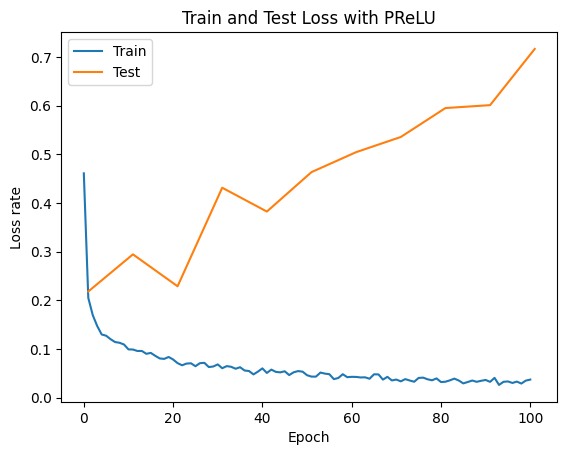

```python
plt.plot(np.arange(n_epochs + 1), train_loss, label="Train")
plt.plot(np.arange(1, n_epochs + 2, 10), test_loss, label="Test")
plt.title("Train and Test Loss with PReLU")
plt.xlabel("Epoch")
plt.ylabel("Loss rate")
plt.legend()
```

## Part 4. Convolutional Layers

### 1. Create a Convolutional Network

**CNN architecture**

[figure not shown]

```python
# CNN model function
def cnn_model(X, w_c1, w_c2, w_c3, w_h2, w_o, p_drop_conv=0.2, p_drop_hidden=0.5):
    h = rectify(conv2d(X, w_c1))
    h = max_pool2d(h, (2, 2))
    h = dropout(h, p_drop_conv)

    h = rectify(conv2d(h, w_c2))
    h = max_pool2d(h, (2, 2))
    h = dropout(h, p_drop_conv)

    h = rectify(conv2d(h, w_c3))
    h = max_pool2d(h, (2, 2))
    h = dropout(h, p_drop_conv)

    h = h.reshape(h.shape[0], -1)

    h2 = rectify(h @ w_h2)
    h2 = dropout (h2, p_drop_hidden)

    pre_softmax = h2 @ w_o
    return pre_softmax
```

```python
# Initialize CNN weights
w_c1 = init_weights((32, 1, 5, 5))
w_c2 = init_weights((64, 32, 5, 5))
w_c3 = init_weights((128, 64, 3, 3))

w_h2_cnn = init_weights((128, 625))
w_o_cnn = init_weights((625, 10))

cnn_params = [w_c1, w_c2, w_c3, w_h2_cnn, w_o_cnn]
optimizer_cnn = RMSprop(params=cnn_params, lr=5e-4)
```

```python
# Error rate function
def compute_cnn_error_rate(dataloader, params):
    n_total = 0
    n_wrong = 0

    with torch.no_grad():
        for x, y in dataloader:
            x = x.reshape(-1, 1, 28, 28)

            logits = cnn_model(
                x,
                *params,
                p_drop_conv=0.0,
                p_drop_hidden=0.0
            )

            predicted = torch.argmax(logits, dim=1)

            n_total += y.shape[0]
            n_wrong += torch.sum(predicted != y).item()

    return n_wrong / n_total
```

### 2. Train CNN

```python
# Train CNN
n_epochs = 20

cnn_train_loss = []
cnn_test_loss = []
cnn_train_error = []
cnn_test_error = []

for epoch in range(1, n_epochs + 1):
    train_loss_this_epoch = []

    for idx, batch in enumerate(train_dataloader):
        x, y = batch

        x = x.reshape(-1, 1, 28, 28)

        logits = cnn_model(
            x,
            w_c1, w_c2, w_c3, w_h2_cnn, w_o_cnn,
            p_drop_conv=0.2,
            p_drop_hidden=0.5
        )

        optimizer_cnn.zero_grad()

        loss = cross_entropy(logits, y, reduction="mean")
        train_loss_this_epoch.append(float(loss))

        loss.backward()
        optimizer_cnn.step()

    cnn_train_loss.append(np.mean(train_loss_this_epoch))

    test_loss_this_epoch = []

    with torch.no_grad():
        for idx, batch in enumerate(test_dataloader):
            x, y = batch

            x = x.reshape(-1, 1, 28, 28)

            logits = cnn_model(
                x,
                w_c1, w_c2, w_c3, w_h2_cnn, w_o_cnn,
                p_drop_conv=0.0,
                p_drop_hidden=0.0
            )

            loss = cross_entropy(logits, y, reduction="mean")
            test_loss_this_epoch.append(float(loss))

    cnn_test_loss.append(np.mean(test_loss_this_epoch))

    train_error = compute_cnn_error_rate(
        train_dataloader,
        [w_c1, w_c2, w_c3, w_h2_cnn, w_o_cnn]
    )

    test_error = compute_cnn_error_rate(
        test_dataloader,
        [w_c1, w_c2, w_c3, w_h2_cnn, w_o_cnn]
    )

    cnn_train_error.append(train_error)
    cnn_test_error.append(test_error)

    print(f"Epoch: {epoch}")
    print(f"Mean train loss: {cnn_train_loss[-1]:.4f}")
    print(f"Mean test loss:  {cnn_test_loss[-1]:.4f}")
    print(f"Train error:     {cnn_train_error[-1]:.4f}")
    print(f"Test error:      {cnn_test_error[-1]:.4f}")
    print()
```

```
Epoch: 1
Mean train loss: 3.9352
Mean test loss:  0.3427
Train error:     0.1039
Test error:      0.0972

Epoch: 2
Mean train loss: 0.5937
Mean test loss:  0.1472
Train error:     0.0475
Test error:      0.0424

Epoch: 3
Mean train loss: 0.3627
Mean test loss:  0.0982
Train error:     0.0319
Test error:      0.0298

Epoch: 4
Mean train loss: 0.2864
Mean test loss:  0.0882
Train error:     0.0255
Test error:      0.0255

Epoch: 5
Mean train loss: 0.2573
Mean test loss:  0.0768
Train error:     0.0230
Test error:      0.0218

Epoch: 6
Mean train loss: 0.2365
Mean test loss:  0.0649
Train error:     0.0192
Test error:      0.0191

Epoch: 7
Mean train loss: 0.2336
Mean test loss:  0.0728
Train error:     0.0190
```

[output cut: 64 more lines]

```
Mean test loss:  0.5327
Train error:     0.0746
Test error:      0.0696

Epoch: 19
Mean train loss: 0.4055
Mean test loss:  0.2833
Train error:     0.0412
Test error:      0.0385

Epoch: 20
Mean train loss: 0.4103
Mean test loss:  0.5312
Train error:     0.0605
Test error:      0.0575
```

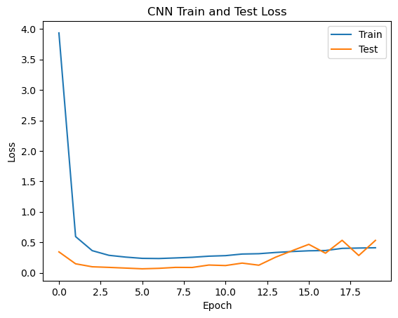

```python
# Plot training curves (Loss)
plt.figure()
plt.plot(np.arange(n_epochs), cnn_train_loss, label="Train")
plt.plot(np.arange(n_epochs), cnn_test_loss, label="Test")
plt.title("CNN Train and Test Loss")
plt.xlabel("Epoch")
plt.ylabel("Loss")
plt.legend()
plt.show()
```

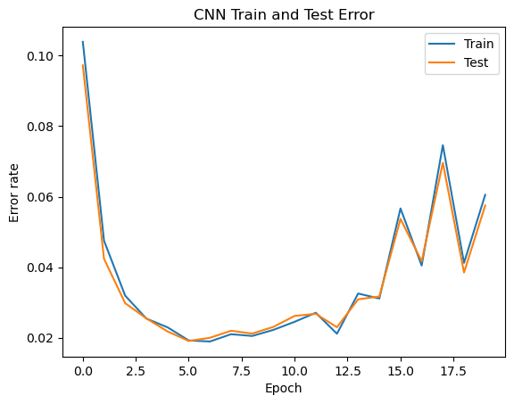

```python
# Plot training curves (Error)
plt.figure()
plt.plot(np.arange(n_epochs), cnn_train_error, label="Train")
plt.plot(np.arange(n_epochs), cnn_test_error, label="Test")
plt.title("CNN Train and Test Error")
plt.xlabel("Epoch")
plt.ylabel("Error rate")
plt.legend()
plt.show()
```

### 3. Plot

```python
# Plot one image from the test set
x_test_example, y_test_example = next(iter(test_dataloader))

image = x_test_example[0:1]
label = y_test_example[0].item()

image_cnn = image.reshape(1, 1, 28, 28)

with torch.no_grad():
    conv1_output = rectify(conv2d(image_cnn, w_c1))

print("True label:", label)
print("Input image shape:", image_cnn.shape)
print("Conv1 output shape:", conv1_output.shape)
print("First layer filter shape:", w_c1.shape)
```

```
True label: 7
Input image shape: torch.Size([1, 1, 28, 28])
Conv1 output shape: torch.Size([1, 32, 24, 24])
First layer filter shape: torch.Size([32, 1, 5, 5])
```

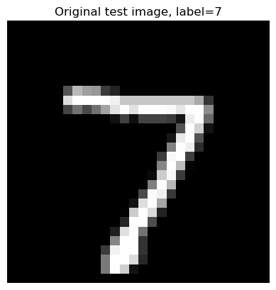

```python
plt.figure()
plt.imshow(image.reshape(28, 28), cmap="gray")
plt.title(f"Original test image, label={label}")
plt.axis("off")
plt.show()
```

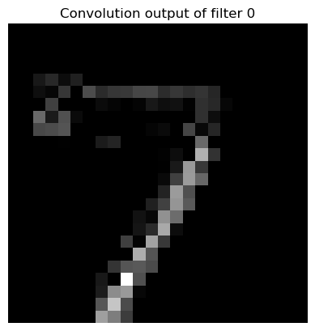

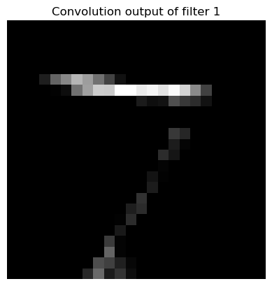

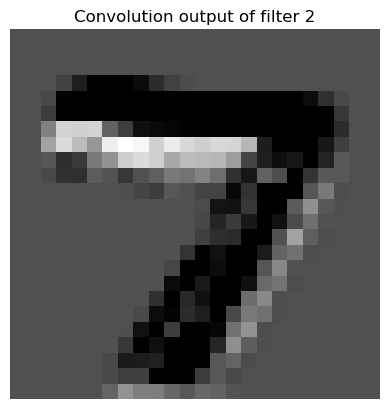

```python
# Plot its convolution with 3 filters of the first convolutional layer
for i in range(3):
    plt.figure()
    plt.imshow(conv1_output[0, i].detach().numpy(), cmap="gray")
    plt.title(f"Convolution output of filter {i}")
    plt.axis("off")
    plt.show()
```

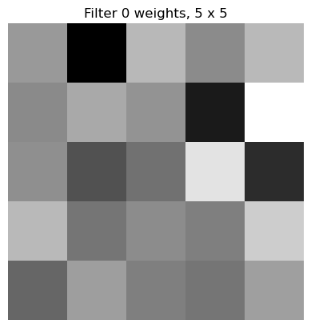

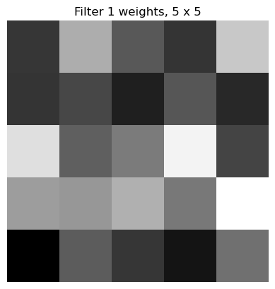

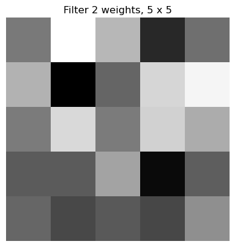

```python
# Plot the corresponding filter weights (these should be 5 by 5 images)
for i in range(3):
    plt.figure()
    plt.imshow(w_c1[i, 0].detach().numpy(), cmap="gray")
    plt.title(f"Filter {i} weights, 5 x 5")
    plt.axis("off")
    plt.show()
```

### 4. Removing one convolutional layer

```python
# modified model function
def cnn_without_conv3_model(X, w_c1, w_c2, w_h2, w_o, p_drop_conv=0.2, p_drop_hidden=0.5):
    # First conv block
    h = rectify(conv2d(X, w_c1))
    h = max_pool2d(h, (2, 2))
    h = dropout(h, p_drop_conv)

    # Second conv block
    h = rectify(conv2d(h, w_c2))
    h = max_pool2d(h, (2, 2))
    h = dropout(h, p_drop_conv)

    # Flatten conv output
    h = h.reshape(h.shape[0], -1)

    # Fully-connected hidden layer
    h2 = rectify(h @ w_h2)
    h2 = dropout (h2, p_drop_hidden)

    # Output layer
    pre_softmax = h2 @ w_o

    return pre_softmax
```

```python
# Initialize CNN weights
w_r1 = init_weights((32, 1, 5, 5))
w_r2 = init_weights((64, 32, 5, 5))

w_h2_removed = init_weights((1024, 625))

w_o_removed = init_weights((625, 10))

removed_params = [w_r1, w_r2, w_h2_removed, w_o_removed]
optimizer_removed = RMSprop(params=removed_params, lr=5e-4)
```

```python
# Error rate function
def compute_removed_cnn_error_rate(dataloader, params):
    n_total = 0
    n_wrong = 0

    with torch.no_grad():
        for x, y in dataloader:
            x = x.reshape(-1, 1, 28, 28)

            logits = cnn_without_conv3_model(
                x,
                *params,
                p_drop_conv=0.0,
                p_drop_hidden=0.0
            )

            predicted = torch.argmax(logits, dim=1)

            n_total += y.shape[0]
            n_wrong += torch.sum(predicted != y).item()

    return n_wrong / n_total
```

```python
# Train CNN without Conv3
n_epochs_removed = n_epochs

removed_train_loss = []
removed_test_loss = []
removed_train_error = []
removed_test_error = []

for epoch in range(1, n_epochs_removed + 1):
    train_loss_this_epoch = []

    for idx, batch in enumerate(train_dataloader):
        x, y = batch

        x = x.reshape(-1, 1, 28, 28)

        logits = cnn_without_conv3_model(
            x,
            w_r1, w_r2, w_h2_removed, w_o_removed,
            p_drop_conv=0.2,
            p_drop_hidden=0.5
        )

        optimizer_removed.zero_grad()

        loss = cross_entropy(logits, y, reduction="mean")
        train_loss_this_epoch.append(float(loss))

        loss.backward()
        optimizer_removed.step()

    removed_train_loss.append(np.mean(train_loss_this_epoch))

    test_loss_this_epoch = []

    with torch.no_grad():
        for idx, batch in enumerate(test_dataloader):
            x, y = batch

            x = x.reshape(-1, 1, 28, 28)

            logits = cnn_without_conv3_model(
                x,
                w_r1, w_r2, w_h2_removed, w_o_removed,
                p_drop_conv=0.0,
                p_drop_hidden=0.0
            )

            loss = cross_entropy(logits, y, reduction="mean")
            test_loss_this_epoch.append(float(loss))

    removed_test_loss.append(np.mean(test_loss_this_epoch))

    train_error = compute_removed_cnn_error_rate(
        train_dataloader,
        [w_r1, w_r2, w_h2_removed, w_o_removed]
    )

    test_error = compute_removed_cnn_error_rate(
        test_dataloader,
        [w_r1, w_r2, w_h2_removed, w_o_removed]
    )

    removed_train_error.append(train_error)
    removed_test_error.append(test_error)

    print(f"Epoch: {epoch}")
    print(f"Mean train loss: {removed_train_loss[-1]:.4f}")
    print(f"Mean test loss:  {removed_test_loss[-1]:.4f}")
    print(f"Train error:     {removed_train_error[-1]:.4f}")
    print(f"Test error:      {removed_test_error[-1]:.4f}")
    print()
```

```
Epoch: 1
Mean train loss: 0.7407
Mean test loss:  0.0856
Train error:     0.0278
Test error:      0.0255

Epoch: 2
Mean train loss: 0.1801
Mean test loss:  0.0697
Train error:     0.0217
Test error:      0.0204

Epoch: 3
Mean train loss: 0.1428
Mean test loss:  0.0750
Train error:     0.0192
Test error:      0.0175

Epoch: 4
Mean train loss: 0.1350
Mean test loss:  0.1036
Train error:     0.0226
Test error:      0.0239

Epoch: 5
Mean train loss: 0.1453
Mean test loss:  0.1661
Train error:     0.0207
Test error:      0.0217

Epoch: 6
Mean train loss: 0.1573
Mean test loss:  0.1831
Train error:     0.0246
Test error:      0.0247

Epoch: 7
Mean train loss: 0.1652
Mean test loss:  0.4863
Train error:     0.0422
```

[output cut: 64 more lines]

```
Mean test loss:  0.4794
Train error:     0.0405
Test error:      0.0414

Epoch: 19
Mean train loss: 0.2629
Mean test loss:  0.4766
Train error:     0.0476
Test error:      0.0463

Epoch: 20
Mean train loss: 0.2706
Mean test loss:  0.4204
Train error:     0.0422
Test error:      0.0440
```

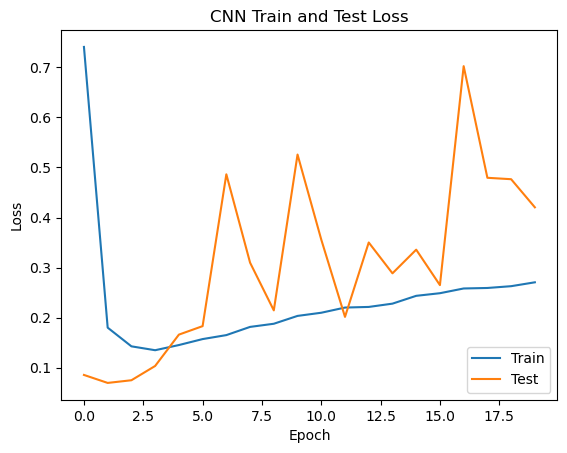

```python
# Plot training curves (Loss)
plt.figure()
plt.plot(np.arange(n_epochs_removed), removed_train_loss, label="Train")
plt.plot(np.arange(n_epochs_removed), removed_test_loss, label="Test")
plt.title("CNN Train and Test Loss")
plt.xlabel("Epoch")
plt.ylabel("Loss")
plt.legend()
plt.show()
```

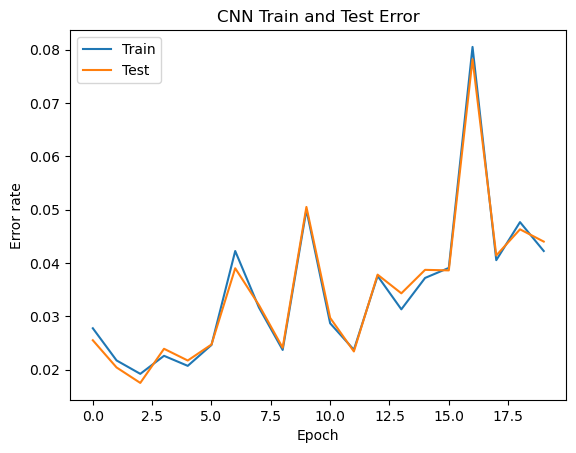

```python
# Plot training curves (Error)
plt.figure()
plt.plot(np.arange(n_epochs_removed), removed_train_error, label="Train")
plt.plot(np.arange(n_epochs_removed), removed_test_error, label="Test")
plt.title("CNN Train and Test Error")
plt.xlabel("Epoch")
plt.ylabel("Error rate")
plt.legend()
plt.show()
```

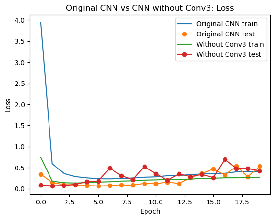

```python
# Plot original CNN vs CNN without Conv3
plt.figure()

plt.plot(np.arange(n_epochs), cnn_train_loss, label="Original CNN train")
plt.plot(np.arange(n_epochs), cnn_test_loss, marker="o", label="Original CNN test")

plt.plot(np.arange(n_epochs_removed), removed_train_loss, label="Without Conv3 train")
plt.plot(np.arange(n_epochs_removed), removed_test_loss, marker="o", label="Without Conv3 test")

plt.title("Original CNN vs CNN without Conv3: Loss")
plt.xlabel("Epoch")
plt.ylabel("Loss")
plt.legend()
plt.show()
```

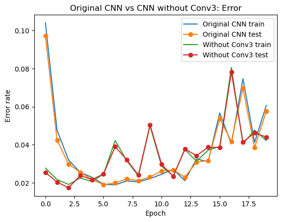

```python
# Plot original CNN vs CNN without Conv3
plt.figure()

plt.plot(np.arange(n_epochs), cnn_train_error, label="Original CNN train")
plt.plot(np.arange(n_epochs), cnn_test_error, marker="o", label="Original CNN test")

plt.plot(np.arange(n_epochs_removed), removed_train_error, label="Without Conv3 train")
plt.plot(np.arange(n_epochs_removed), removed_test_error, marker="o", label="Without Conv3 test")

plt.title("Original CNN vs CNN without Conv3: Error")
plt.xlabel("Epoch")
plt.ylabel("Error rate")
plt.legend()
plt.show()
```

```python
# Overview table

cnn_results = pd.DataFrame({
    "Model": ["Original CNN", "CNN without Conv3"],
    "Architecture": ["Conv1 → Pool → Conv2 → Pool → Conv3 → Pool → FC", "Conv1 → Pool → Conv2 → Pool → FC"],
    "Train error": [cnn_train_error[-1], removed_train_error[-1]],
    "Test error": [cnn_test_error[-1], removed_test_error[-1]],
    "Comment": ["Required CNN with 32, 64, and 128 convolutional filters", "Additional experiment: removed the third convolutional layer"]
})

cnn_results
```

|  | Model | Architecture | Train error | Test error | Comment |
| --- | --- | --- | --- | --- | --- |
| 0 | Original CNN | Conv1 → Pool → Conv2 → Pool → Conv3 → Pool → FC | 0.060517 | 0.0575 | Required CNN with 32, 64, and 128 convolutiona... |
| 1 | CNN without Conv3 | Conv1 → Pool → Conv2 → Pool → FC | 0.042233 | 0.0440 | Additional experiment: removed the third convo... |

#### Discussion

The original CNN and the modified CNN were compared using the train and test error. The modified CNN removes the third convolutional layer. Therefore, the convolutional part is shallower, but the flattened feature vector is larger: 64 x 4 x 4 = 1024, compared to 128 in the original CNN.

In this run, the CNN without Conv3 achieved a lower test error than the original CNN. This suggests that the third convolutional layer did not improve the performance under the current training settings. One possible reason is that MNIST is a relatively simple image classification task, so two convolutional layers may already be sufficient. Another possible reason is optimization instability, since the loss curves show some fluctuations during training.

Overall, the additional experiment shows that increasing the depth of the convolutional part does not automatically improve the test error. The architecture and training hyperparameters must be tuned together.